# Assignment 12/02

## 16.8 Case study: election forecasting

Below, we will use these for our forecasting.

### 16.8.1 Bayesian approach

Pollsters tend to make probabilistic statements about the results of the election. For example, “The chance that Obama wins the electoral college is 91%” is a probabilistic statement about a parameter which in previous sections we have denoted with d . We showed that for the 2016 election, FiveThirtyEight gave Clinton an 81.4% chance of winning the popular vote. To do this, they used the Bayesian approach we described.

For our best guess, we note that before any poll data is available, we can use data sources other than polling data. A popular approach is to use what pollsters call fundamentals, which are based on properties about the current economy that historically appear to have an effect in favor or against the incumbent party. We won’t use these here. Instead, we will use μ=0 , which is interpreted as a model that simply does not provide any information on who will win. For the standard deviation, we will use recent historical data that shows the winner of the popular vote has an average spread of about 3.5%. Therefore, we set τ=0.035 .

Now we can use the formulas for the posterior distribution for the parameter d : the probability of d>0 given the observed poll data:

```r
posterior_se
```

```
[1] 0.006149604
```

To make a probability statement, we use the fact that the posterior distribution is also normal. And we have a credible interval of:

```r
posterior_mean + c(-1.96, 1.96)*posterior_se
```

```
[1] 0.01603212 0.04013857
```

The posterior probability Pr(d>0∣¯X) can be computed like this:

```r
1 - pnorm(0, posterior_mean, posterior_se)
```

```
[1] 0.9999975
```

This says we are 100% sure Clinton will win the popular vote, which seems too overconfident. Also, it is not in agreement with FiveThirtyEight’s 81.4%. What explains this difference?

16.8.2 The general bias After elections are over, one can look at the difference between pollster predictions and actual result. An important observation that our model does not take into account is that it is common to see a general bias that affects many pollsters in the same way making the observed data correlated. There is no good explanation for this, but we do observe it in historical data: in one election, the average of polls favors Democrats by 2%, then in the following election they favor Republicans by 1%, then in the next election there is no bias, then in the following one Republicans are favored by 3%, and so on. In 2016, the polls were biased in favor of the Democrats by 1-2%.

Although we know this bias term affects our polls, we have no way of knowing what this bias is until election night. So we can’t correct our polls accordingly. What we can do is include a term in our model that accounts for this variability.

### 16.8.3 Mathematical representations of models

Suppose we are collecting data from one pollster and we assume there is no general bias. The pollster collects several polls with a sample size of N , so we observe several measurements of the spread X1,…,XJ . The theory tells us that these random variables have expected value d and standard error 2√p(1−p)/N . Let’s start by using the following model to describe the observed variability: Xj=d+εj.

We use the index j to represent the different polls and we define εj to be a random variable that explains the poll-to-poll variability introduced by sampling error. To do this, we assume its average is 0 and standard error is 2√p(1−p)/N . If d is 2.1 and the sample size for these polls is 2,000, we can simulate J=6 data points from this model like this:

Now suppose we have J=6 data points from I=5 different pollsters. To represent this we now need two indexes, one for pollster and one for the polls each pollster takes. We use Xij with i representing the pollster and j representing the j -th poll from that pollster. If we apply the same model, we write:

Xi,j=d+εi,j

To simulate data, we now have to loop through the pollsters:

The model above does not account for pollster-to-pollster variability. To fix this, we add a new term for the pollster effect. We will use hi to represent the house effect of the i -th pollster. The model is now augmented to

Note that hi is common to all the observed spreads from a specific pollster. Different pollsters have a different hi , which explains why we can see the groups of points shift up and down from pollster to pollster.

Now, in the model above, we assume the average house effect is 0. We think that for every pollster biased in favor of our party, there is another one in favor of the other and assume the standard deviation is σh . But historically we see that every election has a general bias affecting all polls. We can observe this with the 2016 data, but if we collect historical data, we see that the average of polls misses by more than models like the one above predict. To see this, we would take the average of polls for each election year and compare it to the actual value. If we did this, we would see a difference with a standard deviation of between 2-3%. To incorporate this into the model, we can add another term to account for this variability:Xi,j=d+b+hi+εi,j.

Here b is a random variable that accounts for the election-to-election variability. This random variable changes from election to election, but for any given election, it is the same for all pollsters and polls within on election. This is why it does not have indexes. This implies that all the random variables Xi,j for an election year are correlated since they all have b in common.

One way to interpret b is as the difference between the average of all polls from all pollsters and the actual result of the election. Because we don’t know the actual result until after the election, we can’t estimate b until after the election. However, we can estimate b from previous elections and study the distribution of these values. Based on this approach we assume that, across election years, b has expected value 0 and the standard error is about σb=0.025 .

An implication of adding this term to the model is that the standard deviation for Xi,j is actually higher than what we earlier called σ , which combines the pollster variability and the sample in variability, and was estimated with:

```r
sd(one_poll_per_pollster$spread)
```

```
[1] 0.02419369
```

Since the same b is in every measurement, the average does not reduce the variability introduced by the b term. This is an important point: it does not matter how many polls you take, this bias does not get reduced.

If we redo the Bayesian calculation taking this variability into account, we get a result much closer to FiveThirtyEight’s:

```r
1 - pnorm(0, posterior_mean, posterior_se)
```

```
[1] 0.8174373
```

### 16.8.4 Predicting the electoral college

Up to now we have focused on the popular vote. But in the United States, elections are not decided by the popular vote but rather by what is known as the electoral college. Each state gets a number of electoral votes that depends, in a somewhat complex way, on the population size of the state. Here are the top 5 states ranked by electoral votes in 2016.

| state | electoral_votes | clinton | trump | others |
| --- | --- | --- | --- | --- |
| California | 55 | 61.7 | 31.6 | 6.7 |
| Texas | 38 | 43.2 | 52.2 | 4.5 |
| Florida | 29 | 47.8 | 49.0 | 3.2 |
| New York | 29 | 59.0 | 36.5 | 4.5 |
| Illinois | 20 | 55.8 | 38.8 | 5.4 |
| Pennsylvania | 20 | 47.9 | 48.6 | 3.6 |

With some minor exceptions we don’t discuss, the electoral votes are won all or nothing. For example, if you win California by just 1 vote, you still get all 55 of its electoral votes. This means that by winning a few big states by a large margin, but losing many small states by small margins, you can win the popular vote and yet lose the electoral college. This happened in 1876, 1888, 2000, and 2016. The idea behind this is to avoid a few large states having the power to dominate the presidential election. Nonetheless, many people in the US consider the electoral college unfair and would like to see it abolished.

We are now ready to predict the electoral college result for 2016. We start by aggregating results from a poll taken during the last week before the election. We use the `str_detect`, a function we introduce later in Section 24.1, to remove polls that are not for entire states.

Here are the five closest races according to the polls:

| state | avg | sd | n |
| --- | --- | --- | --- |
| Florida | 0.003557143 | 0.0163496032 | 7 |
| North Carolina | -0.007300000 | 0.0306208262 | 9 |
| Ohio | -0.010416667 | 0.0252247828 | 6 |
| Nevada | 0.016857143 | 0.0440680858 | 7 |
| Iowa | -0.019733333 | 0.0436647837 | 3 |
| Michigan | 0.020950000 | 0.0202606762 | 6 |
| Arizona | -0.032644444 | 0.0269547357 | 9 |
| Pennsylvania | 0.035333333 | 0.0116052790 | 9 |
| New Mexico | 0.038933333 | 0.0225518661 | 6 |
| Georgia | -0.044850000 | 0.0238115518 | 4 |

[output cut: 37 more lines]

We now introduce the command `left_join` that will let us easily add the number of electoral votes for each state from the dataset `us_electoral_votes_2016`. We will describe this function in detail in the Wrangling chapter. Here, we simply say that the function combines the two datasets so that the information from the second argument is added to the information in the first:

Notice that some states have no polls because the winner is pretty much known:

```r
results_us_election_2016 %>% filter(!state %in% results$state) %>%
  pull(state)
```

```
[1] "Rhode Island"         "Alaska"
[3] "Wyoming"              "District of Columbia"
```

No polls were conducted in DC, Rhode Island, Alaska, and Wyoming because Democrats are sure to win in the first two and Republicans in the last two.

Because we can’t estimate the standard deviation for states with just one poll, we will estimate it as the median of the standard deviations estimated for states with more than one poll:

To make probabilistic arguments, we will use a Monte Carlo simulation. For each state, we apply the Bayesian approach to generate an election day d . We could construct the priors for each state based on recent history. However, to keep it simple, we assign a prior to each state that assumes we know nothing about what will happen. Since from election year to election year the results from a specific state don’t change that much, we will assign a standard deviation of 2% or τ=0.02 . For now, we will assume, incorrectly, that the poll results from each state are independent. The code for the Bayesian calculation under these assumptions looks like this:

```
#> # A tibble: 47 x 12
#>   state     avg      sd     n electoral_votes clinton trump others
#>   <chr>   <dbl>   <dbl> <int>           <int>   <dbl> <dbl>  <dbl>
#> 1 Alab… -0.149  2.53e-2     3               9    34.4  62.1    3.6
#> 2 Ariz… -0.0326 2.70e-2     9              11    45.1  48.7    6.2
#> 3 Arka… -0.151  9.90e-4     2               6    33.7  60.6    5.8
#> 4 Cali…  0.260  3.87e-2     5              55    61.7  31.6    6.7
#> 5 Colo…  0.0452 2.95e-2     7               9    48.2  43.3    8.6
#> # … with 42 more rows, and 4 more variables: sigma <dbl>, B <dbl>,
#> #   posterior_mean <dbl>, posterior_se <dbl>
```

The estimates based on posterior do move the estimates towards 0, although the states with many polls are influenced less. This is expected as the more poll data we collect, the more we trust those results:

The model above ignores the general bias and assumes the results from different states are independent. After the election, we realized that the general bias in 2016 was not that big: it was between 1 and 2%. But because the election was close in several big states and these states had a large number of polls, pollsters that ignored the general bias greatly underestimated the standard error. Using the notation we introduce, they assumed the standard error was √σ2/N which with large N is quite smaller than the more accurate estimate √σ2/N+σ2b . FiveThirtyEight, which models the general bias in a rather sophisticated way, reported a closer result. We can simulate the results now with a bias term. For the state level, the general bias can be larger so we set it at σb=0.03 :

```r
mean(clinton_EV_2 > 269)
```

```
[1] 0.836
```

This gives us a much more sensible estimate. Looking at the outcomes of the simulation, we see how the bias term adds variability to the final results.

FiveThirtyEight includes many other features we do not include here. One is that they model variability with distributions that have high probabilities for extreme events compared to the normal. One way we could do this is by changing the distribution used in the simulation from a normal distribution to a t-distribution. FiveThirtyEight predicted a probability of 71%.

### 16.8.5 Forecasting

Forecasters like to make predictions well before the election. The predictions are adapted as new polls come out. However, an important question forecasters must ask is: how informative are polls taken several weeks before the election about the actual election? Here we study the variability of poll results across time.

To make sure the variability we observe is not due to pollster effects, let’s study data from one pollster:

Since there is no pollster effect, then perhaps the theoretical standard error matches the data-derived standard deviation. We compute both here:

| empirical | theoretical |
| --- | --- |
| 0.04025194 | 0.03256719 |

Some of the peaks and valleys we see coincide with events such as the party conventions, which tend to give the candidate a boost. We can see the peaks and valleys are consistent across several pollsters:

Once a model like the one above is selected, we can use historical and present data to estimate all the necessary parameters to make predictions. There is a variety of methods for estimating trends f(t) which we discuss in the Machine Learning part.

## 16.9 Exercises

1. Create this table:

Now for each poll use the CLT to create a 95% confidence interval for the spread reported by each poll. Call the resulting object cis with columns lower and upper for the limits of the confidence intervals. Use the `select` function to keep the columns `state, startdate, end date, pollster, grade, spread, lower, upper`.

2. You can add the final result to the cis table you just created using the `right_join` function like this:

Now determine how often the 95% confidence interval includes the actual result.

| pr_in |
| --- |
| 0.66133 |

| pollster | pr_hits | n | grade |
| --- | --- | --- | --- |
| Quinnipiac University | 1.0000000 | 6 | A- |
| Emerson College | 0.9090909 | 11 | B |
| Public Policy Polling | 0.8888889 | 9 | B+ |
| University of New Hampshire | 0.8571429 | 7 | B+ |
| Ipsos | 0.8067227 | 119 | A- |
| Mitchell Research & Communications | 0.8000000 | 5 | D |
| Gravis Marketing | 0.7826087 | 23 | B- |
| Trafalgar Group | 0.7777778 | 9 | C |
| Rasmussen Reports/Pulse Opinion Research | 0.7741935 | 31 | C+ |
| Remington | 0.6666667 | 9 | NA |

[output cut: 3 more lines]

4. Repeat exercise 3, but instead of pollster, stratify by state. Note that here we can’t show grades.

| state | proportion_hit | n |
| --- | --- | --- |
| Alabama | 0.1538462 | 13 |
| Alaska | 0.8181818 | 11 |
| Arizona | 0.7142857 | 21 |
| Arkansas | 0.4166667 | 12 |
| California | 0.3750000 | 16 |
| Colorado | 0.9130435 | 23 |
| Connecticut | 1.0000000 | 13 |
| Delaware | 1.0000000 | 12 |
| District of Columbia | 0.5000000 | 10 |
| Florida | 0.8620690 | 29 |

[output cut: 41 more lines]

5. Make a barplot based on the result of exercise 4. Use `coord_flip`.

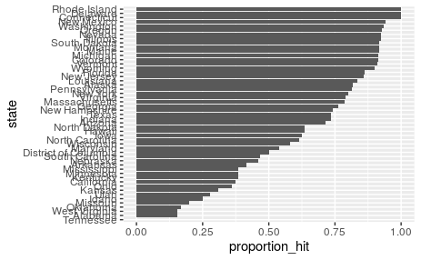

6. Add two columns to the `cis` table by computing, for each poll, the difference between the predicted spread and the actual spread, and define a column `hit` that is true if the signs are the same. Hint: use the function `sign`. Call the object `resids`.

```r
resids <- cis %>% mutate(error = spread - actual_spread, hit = sign(spread)==sign(actual_spread))
```

[output not shown]

7. Create a plot like in exercise 5, but for the proportion of times the sign of the spread agreed.

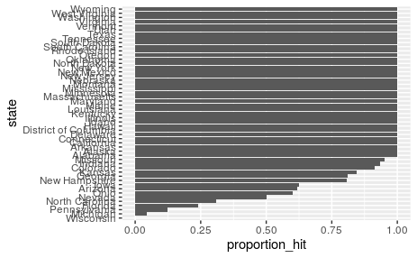

8. In exercise 7, we see that for most states the polls had it right 100% of the time. For only 9 states did the polls miss more than 25% of the time. In particular, notice that in Wisconsin every single poll got it wrong. In Pennsylvania and Michigan more than 90% of the polls had the signs wrong. Make a histogram of the errors. What is the median of these errors?

```r
median(resids$error)
```

```
[1] 0.037
```

9. We see that at the state level, the median error was 3% in favor of Clinton. The distribution is not centered at 0, but at 0.03. This is the general bias we described in the section above. Create a boxplot to see if the bias was general to all states or it affected some states differently. Use `filter(grade %in% c("A+","A","A-","B+") | is.na(grade)))` to only include pollsters with high grades.

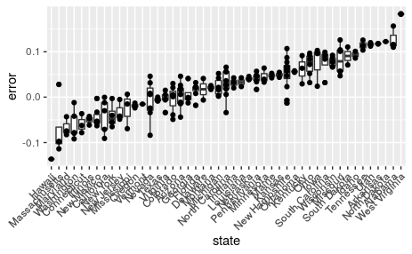

10. Some of these states only have a few polls. Repeat exercise 9, but only include states with 5 good polls or more. Hint: use `group_by`, `filter` then `ungroup`. You will see that the West (Washington, New Mexico, California) underestimated Hillary’s performance, while the Midwest (Michigan, Pennsylvania, Wisconsin, Ohio, Missouri) overestimated it. In our simulation, we did not model this behavior since we added general bias, rather than a regional bias. Note that some pollsters may now be modeling correlation between similar states and estimating this correlation from historical data. To learn more about this, you can learn about random effects and mixed models.

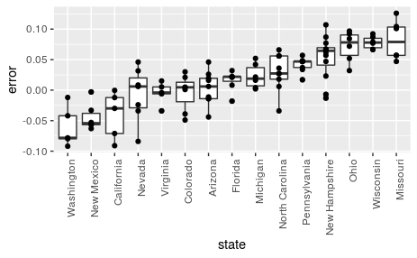

## 16.10 The t-distribution

Above we made use of the CLT with a sample size of 15. Because we are estimating a second parameters σ , further variability is introduced into our confidence interval which results in intervals that are too small. For very large sample sizes this extra variability is negligible, but, in general, for values smaller than 30 we need to be cautious about using the CLT.

However, if the data in the urn is known to follow a normal distribution, then we actually have mathematical theory that tells us how much bigger we need to make the intervals to account for the estimation of σ . Using this theory, we can construct confidence intervals for any N . But again, this works only if **the data in the urn is known to follow a normal distribution**. So for the 0, 1 data of our previous urn model, this theory definitely does not apply.

The statistic on which confidence intervals for d are based is CLT tells us that Z is approximately normally distributed with expected value 0 and standard error 1. But in practice we don’t know σ so we use:

If we are willing to assume the pollster effect data is normally distributed, based on the sample data X1,…,XN ,

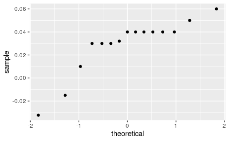

then Z follows a t-distribution with N−1 degrees of freedom. So perhaps a better confidence interval for d is:

| avg | moe | start | end |
| --- | --- | --- | --- |
| 0.02898 | 0.01339802 | 0.01558198 | 0.04237802 |

A bit larger than the one using normal is

```r
qt(0.975, 14)
```

```
[1] 2.144787
```

is bigger than

```r
qnorm(0.975)
```

```
[1] 1.959964
```

The t-distribution can also be used to model errors in bigger deviations that are more likely than with the normal distribution, as seen in the densities we previously saw. Fivethirtyeight uses the t-distribution to generate errors that better model the deviations we see in election data. For example, in Wisconsin the average of six polls was 7% in favor of Clinton with a standard deviation of 1%, but Trump won by 0.7%. Even after taking into account the overall bias, this 7.7% residual is more in line with t-distributed data than the normal distribution.

| actual | avg | sd | n |
| --- | --- | --- | --- |
| -0.007 | 0.07106667 | 0.01041454 | 6 |